# R & RStudio for Researchers

Workshop Pt. 2: wrangling, figures, statistics and reports

Vrinda Malhotra

2026-11-15

## Today

| Segment | Topic | Time |
| --- | --- | --- |
| Recap | Pt. 1 in five minutes | 5 min |
| Module 1 | Wrangling: reshaping and summarising data | 30 min |
| Module 2 | Figures with ggplot2 | 30 min |
| Module 3 | Statistics: t-test, ANOVA, regression | 35 min |
| Module 4 | Reproducible reports with Quarto | 15 min |
| Wrap-up | Take-home project, questions | 5 min |

All of today’s code in one file: pt2-code.R

# Recap: Pt. 1 in five minutes

5 minutes

## Start-up

Open your project by double-clicking the `.Rproj` file, then run:

```r
library(tidyverse)
library(palmerpenguins)
library(here)
library(broom)     # new today: tidy model results
library(emmeans)   # new today: group comparisons
```

→ Check: does `getwd()` show your project folder?

## Quick check 3 min

1. What does `x <- 5` do?
2. In `mean(x, na.rm = TRUE)`, what is the function and what are the arguments?
3. If `temps <- c(18, 25, 31)`, what does `temps[temps > 24]` give?
1. Stores the value 5 under the name `x`
2. Function `mean`; arguments `x` and `na.rm = TRUE`
3. `25 31`: the values where the condition is `TRUE`

## A data frame is a table of vectors

Each **column** is a vector, like the ones you made in Pt. 1. Each **row** is one observation.

```r
penguins$body_mass_g[1:6]
```

```
[1] 3750 3800 3250   NA 3450 3650
```

```r
mean(penguins$body_mass_g, na.rm = TRUE)
```

```
[1] 4201.754
```

`$` pulls one column out of a table: `table$column`. Today you’ll mostly refer to columns **by name** inside functions instead.

# Module 1: Wrangling data

30 minutes

## The pipe `|>`: “and then”

Most analyses are a chain of steps. There are two ways to write a chain:

|  | Nested: read inside out | Piped: read left to right |
| --- | --- | --- |
| **Math** | g(f(x)) | x → f → g |
| **Everyday** | bake(mix(sift(flour))) | take flour, **and then** sift, **and then** mix, **and then** bake |
| **R** | `round(mean(c(1.2, 5.7)), 1)` | `c(1.2, 5.7) \|> mean() \|> round(1)` |

`|>` passes the result on the left into the first argument of the function on the right. Shortcut: **Ctrl+Shift+M** / **Cmd+Shift+M**.

## Five verbs do most of the work

| Verb | What it does | Spreadsheet equivalent |
| --- | --- | --- |
| `filter()` | Keep rows that meet a condition | Filter menu |
| `select()` | Keep or drop columns | Hide columns |
| `arrange()` | Sort rows | Sort button |
| `mutate()` | Add or change a column | New column with a formula, filled down |
| `summarise()` | Collapse rows into a summary | Pivot table |

Each one takes a data frame in and gives a data frame back, so they chain together with `|>`.

## `filter()`: keep rows

Uses the **conditions** from Pt. 1. A comma means “and”.

```r
penguins |>
  filter(species == "Gentoo", body_mass_g > 5800)
```

```
# A tibble: 9 × 8
  species island bill_length_mm bill_depth_mm flipper_length_mm body_mass_g
  <fct>   <fct>           <dbl>         <dbl>             <int>       <int>
1 Gentoo  Biscoe           48.4          14.6               213        5850
2 Gentoo  Biscoe           49.3          15.7               217        5850
3 Gentoo  Biscoe           49.2          15.2               221        6300
4 Gentoo  Biscoe           59.6          17                 230        6050
5 Gentoo  Biscoe           51.1          16.3               220        6000
6 Gentoo  Biscoe           45.2          16.4               223        5950
7 Gentoo  Biscoe           49.8          15.9               229        5950
8 Gentoo  Biscoe           55.1          16                 230        5850
9 Gentoo  Biscoe           48.8          16.2               222        6000
# ℹ 2 more variables: sex <fct>, year <int>
```

## `select()` and `arrange()`: choose columns, sort rows

```r
penguins |>
  select(species, island, body_mass_g) |>
  arrange(desc(body_mass_g))       # desc() = largest first
```

```
# A tibble: 344 × 3
  species island body_mass_g
  <fct>   <fct>        <int>
1 Gentoo  Biscoe        6300
2 Gentoo  Biscoe        6050
3 Gentoo  Biscoe        6000
4 Gentoo  Biscoe        6000
5 Gentoo  Biscoe        5950
# ℹ 339 more rows
```

R shows the first few rows and tells you how many more there are.

## `mutate()`: add a column

Like typing a formula in a new spreadsheet column and filling it down.

```r
penguins |>
  mutate(mass_kg = body_mass_g / 1000) |>
  select(species, body_mass_g, mass_kg)
```

```
# A tibble: 344 × 3
  species body_mass_g mass_kg
  <fct>         <int>   <dbl>
1 Adelie         3750    3.75
2 Adelie         3800    3.8
3 Adelie         3250    3.25
4 Adelie           NA   NA
5 Adelie         3450    3.45
# ℹ 339 more rows
```

## `group_by()` + `summarise()`: the pivot table

344 penguinsone table

→

group_by(species)split

→

summarise(…)summarise each group

→

3 rowsone per species

```r
penguins |>
  group_by(species) |>
  summarise(n = n(),
            mean_g = mean(body_mass_g, na.rm = TRUE),
            sd_g = sd(body_mass_g, na.rm = TRUE))
```

```
# A tibble: 3 × 4
  species       n mean_g  sd_g
  <fct>     <int>  <dbl> <dbl>
1 Adelie      152  3701.  459.
2 Chinstrap    68  3733.  384.
3 Gentoo      124  5076.  504.
```

## Exercise: wrangle 5 min

1. Keep only penguins from **Dream** island.
2. Add a column `bill_ratio` = bill length ÷ bill depth.
3. Find the mean `bill_ratio` per species, highest first.

```r
penguins |>
  filter(island == "Dream") |>
  mutate(bill_ratio =
    bill_length_mm / bill_depth_mm) |>
  group_by(species) |>
  summarise(mean_ratio =
    mean(bill_ratio, na.rm = TRUE)) |>
  arrange(desc(mean_ratio))
```

```
# A tibble: 2 × 2
  species   mean_ratio
  <fct>          <dbl>
1 Chinstrap       2.65
2 Adelie          2.11
```

## Reshape: wide to long

Remember tidy data from Pt. 1? `pivot_longer()` fixes data with a variable hidden in the column names.

```r
scores
```

```
# A tibble: 2 × 3
     id week1 week2
  <int> <dbl> <dbl>
1     1   5.1   5.6
2     2   4.8   5
```

```r
scores |>
  pivot_longer(c(week1, week2),
               names_to = "week",
               values_to = "score")
```

```
# A tibble: 4 × 3
     id week  score
  <int> <chr> <dbl>
1     1 week1   5.1
2     1 week2   5.6
3     2 week1   4.8
4     2 week2   5
```

`pivot_wider()` goes the other way.

## Cleaning messy column names

Real exports have names like `"Body Mass (g)"`, which are awkward to type. `clean_names()` from the **janitor** package fixes them all at once.

```r
names(penguins_raw)[10:13]
```

```
[1] "Culmen Length (mm)"  "Culmen Depth (mm)"   "Flipper Length (mm)"
[4] "Body Mass (g)"
```

```r
clean <- janitor::clean_names(penguins_raw)
names(clean)[10:13]
```

```
[1] "culmen_length_mm"  "culmen_depth_mm"   "flipper_length_mm"
[4] "body_mass_g"
```

`janitor::clean_names()` means “the `clean_names` function from the janitor package”, without loading the whole package with `library()`.

# Module 2: Figures with ggplot2

30 minutes

## A plot is three choices

Describe a chart to a colleague and you’ve already written it:

> “Using the **penguins** data, put **flipper length** on the x-axis and **body mass** on the y-axis, colour by **species**, and draw **points**.”

| Choice | In the sentence | In ggplot2 |
| --- | --- | --- |
| **Data** | the penguins data | `ggplot(penguins, …)` |
| **Aesthetics**: which column goes where | flipper length on x, mass on y, colour by species | `aes(x = …, y = …, colour = …)` |
| **Geometry**: what shape to draw | points | `geom_point()` |

## Build it up: 1. data and axes

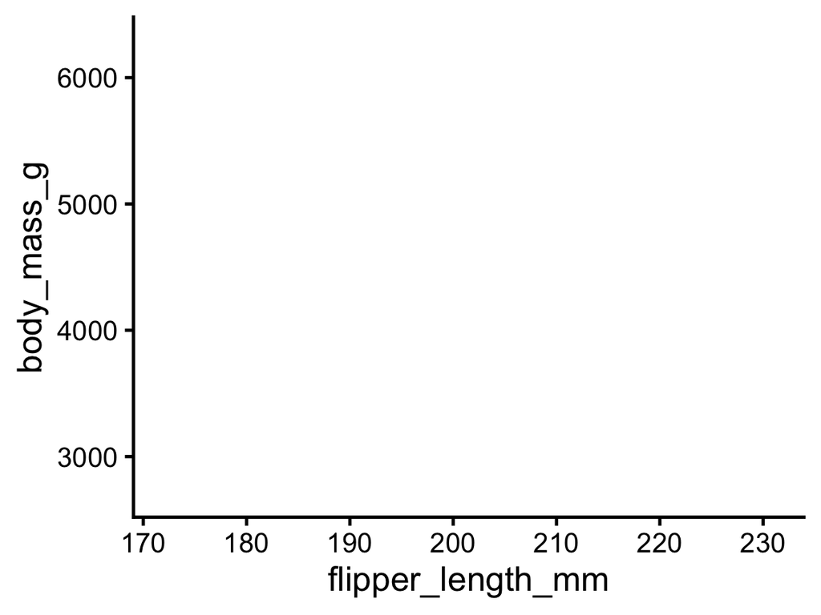

```r
ggplot(penguins,
       aes(x = flipper_length_mm,
           y = body_mass_g))
```

Axes, but nothing drawn yet: we haven’t chosen a geometry.

## Build it up: 2. add points

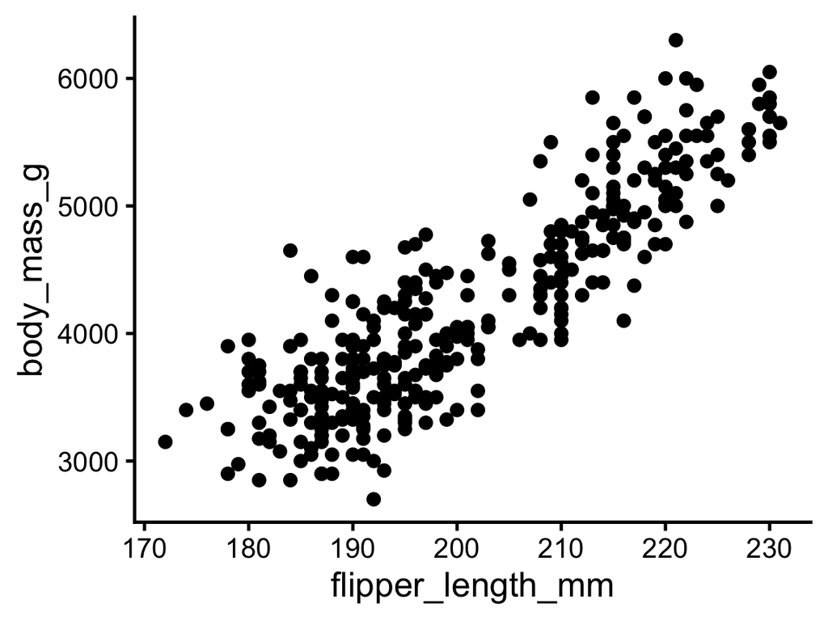

```r
ggplot(penguins,
       aes(x = flipper_length_mm,
           y = body_mass_g)) +
  geom_point()
```

Layers are added with **`+`**, not `|>`. Mixing them up is a common slip.

## Build it up: 3. colour and labels

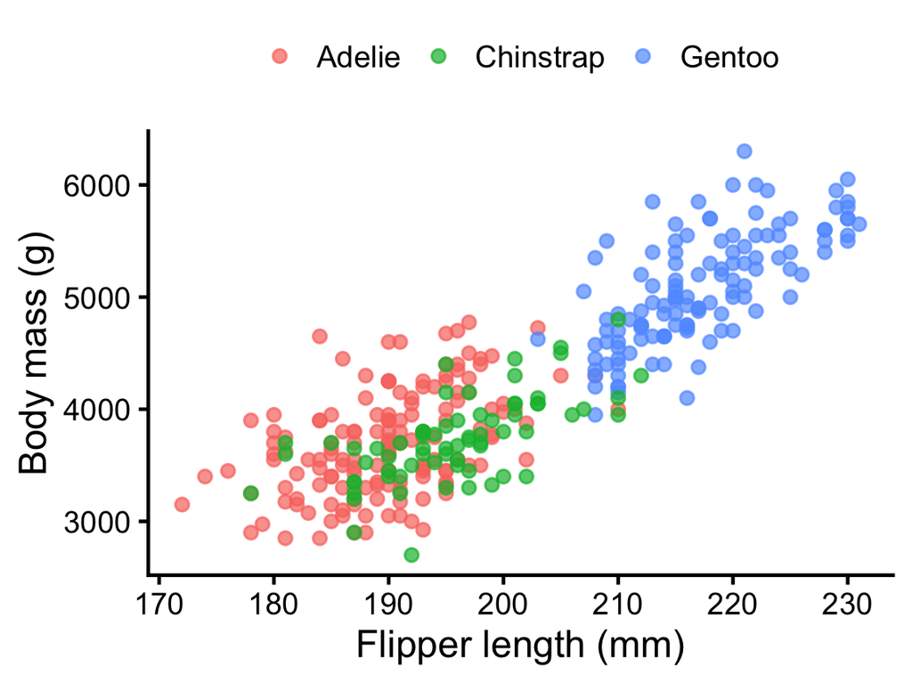

```r
ggplot(penguins,
       aes(x = flipper_length_mm,
           y = body_mass_g,
           colour = species)) +
  geom_point(alpha = 0.7) +
  labs(x = "Flipper length (mm)",
       y = "Body mass (g)",
       colour = NULL) +
  theme(legend.position = "top")
```

## Which plot for which question?

| Question | Geometry |
| --- | --- |
| How do two measurements relate? | `geom_point()`, plus `geom_smooth(method = "lm")` for a trend line |
| How is one measurement spread across groups? | `geom_boxplot()` with `geom_jitter()` on top |
| How does something change over time? | `geom_line()` |
| How many in each category? | `geom_bar()` |
| What does one measurement’s distribution look like? | `geom_histogram()` |

## Show the data, not just the average

A bar of means hides how many points there are and how they’re spread. Show them.

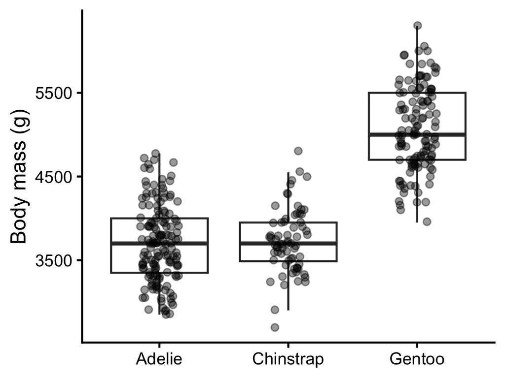

```r
ggplot(penguins,
       aes(x = species,
           y = body_mass_g)) +
  geom_boxplot(outlier.shape = NA) +
  geom_jitter(width = 0.15,
              alpha = 0.4) +
  labs(x = NULL,
       y = "Body mass (g)")
```

## Small multiples: one panel per group

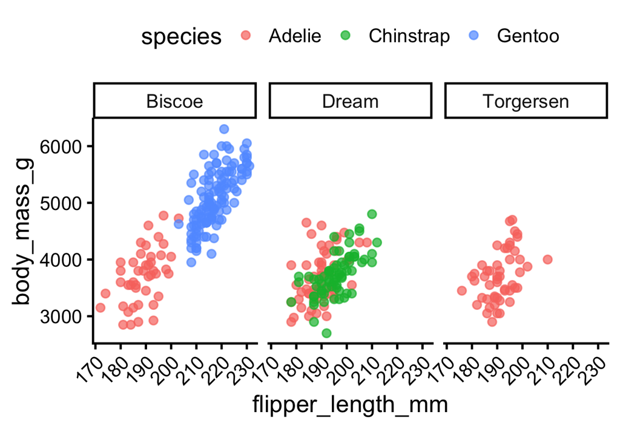

```r
ggplot(penguins,
       aes(x = flipper_length_mm,
           y = body_mass_g,
           colour = species)) +
  geom_point(alpha = 0.7) +
  facet_wrap(~ island) +
  theme(legend.position = "top",
        axis.text.x = element_text(angle = 45, hjust = 1))
```

`facet_wrap(~ island)`: “one panel for each island”. Often clearer than many colours on one panel.

## Save figures from code

```r
my_plot <- ggplot(penguins, aes(flipper_length_mm, body_mass_g)) +
  geom_point()

ggsave(here("figures", "fig1.pdf"), my_plot,
       width = 85, height = 70, units = "mm")       # vector: sharp at any size

ggsave(here("figures", "fig1.png"), my_plot,
       width = 85, height = 70, units = "mm", dpi = 600)
```

- Saving from code records the size and resolution, so the figure is identical every time.
- Journals often want single-column figures 85–90 mm wide and double-column 170–180 mm. Check your journal’s guide.

## Exercise: plot 5 min

1. Make a boxplot of **bill depth** by species, with the points on top.
2. Then give each **sex** its own panel. First drop missing sex with `filter()`. Hint: `!` means NOT, so `!is.na(sex)` is TRUE when sex is **not** missing.

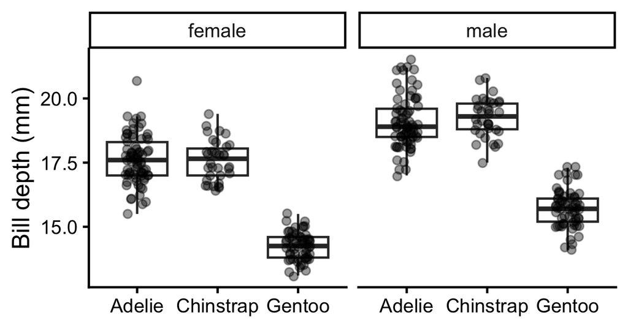

```r
penguins |>
  filter(!is.na(sex)) |>
  ggplot(aes(x = species,
             y = bill_depth_mm)) +
  geom_boxplot(outlier.shape = NA) +
  geom_jitter(width = 0.15, alpha = 0.4) +
  facet_wrap(~ sex) +
  labs(x = NULL, y = "Bill depth (mm)")
```

# Module 3: Statistics

35 minutes

## Formulas: “explained by”

R’s statistics functions describe a model with `~`, read as **“explained by”**.

|  | Example |
| --- | --- |
| **Math** | y = f(x): y depends on x |
| **Everyday** | “Does body mass depend on species?” |
| **R** | `body_mass_g ~ species` |

| Formula | Meaning |
| --- | --- |
| `y ~ x` | y explained by x |
| `y ~ x1 + x2` | y explained by x1 and x2 together |
| `y ~ x1 * x2` | the same, plus: does the effect of x1 depend on x2? (interaction) |

## Which test?

| Question | Test | R function |
| --- | --- | --- |
| Do **two** groups differ on average? | t-test | `t.test(y ~ group)` |
| Do **three or more** groups differ? | ANOVA | `aov(y ~ group)` |
| How does y change with x, accounting for other variables? | Linear regression | `lm(y ~ x1 + x2)` |

All three take a formula and `data =`, so once you can write one, you can write them all.

## t-test: do male and female Adelie differ in mass?

```r
adelie <- penguins |> filter(species == "Adelie", !is.na(sex))

t.test(body_mass_g ~ sex, data = adelie)
```

```
    Welch Two Sample t-test

data:  body_mass_g by sex
t = -13.126, df = 135.69, p-value < 2.2e-16
alternative hypothesis: true difference in means between group female and group male is not equal to 0
95 percent confidence interval:
 -776.3012 -573.0139
sample estimates:
mean in group female   mean in group male
            3368.836             4043.493
```

## ANOVA: three or more groups

Does body mass differ between the three species?

```r
fit_aov <- aov(body_mass_g ~ species, data = penguins)
summary(fit_aov)
```

```
             Df    Sum Sq  Mean Sq F value Pr(>F)
species       2 146864214 73432107   343.6 <2e-16 ***
Residuals   339  72443483   213698
---
Signif. codes:  0 '***' 0.001 '**' 0.01 '*' 0.05 '.' 0.1 ' ' 1
2 observations deleted due to missingness
```

A small p-value (`Pr(>F)`) says **at least one** species differs. It doesn’t say which.

## Which groups differ?

A **post-hoc** test compares every pair, adjusting for doing several tests at once.

```r
emmeans(fit_aov, pairwise ~ species)$contrasts
```

```
 contrast           estimate   SE  df t.ratio p.value
 Adelie - Chinstrap    -32.4 67.5 339  -0.480  0.8807
 Adelie - Gentoo     -1375.4 56.1 339 -24.495 <0.0001
 Chinstrap - Gentoo  -1342.9 69.9 339 -19.224 <0.0001

P value adjustment: tukey method for comparing a family of 3 estimates
```

Gentoo differ from both other species; Adelie and Chinstrap don’t differ clearly.

## Linear regression

How does body mass change with flipper length, accounting for species?

```r
fit_lm <- lm(body_mass_g ~ flipper_length_mm + species, data = penguins)
```

`tidy()` from the **broom** package turns the result into a table:

```r
tidy(fit_lm, conf.int = TRUE) |>
  select(term, estimate, conf.low, conf.high, p.value)
```

```
# A tibble: 4 × 5
  term              estimate conf.low conf.high  p.value
  <chr>                <dbl>    <dbl>     <dbl>    <dbl>
1 (Intercept)        -4031.   -5181.    -2882.  2.55e-11
2 flipper_length_mm     40.7     34.7      46.7 1.40e-32
3 speciesChinstrap    -207.    -320.      -93.0 3.98e- 4
4 speciesGentoo        267.      79.4     454.  5.39e- 3
```

## Reading the coefficients

| Term | Means |
| --- | --- |
| `flipper_length_mm` | Each extra mm of flipper adds about **40.7 g**, within a species |
| `speciesChinstrap`, `speciesGentoo` | Difference from **Adelie** at the same flipper length. Gentoo: **267 g** heavier |
| `(Intercept)` | Predicted mass for an Adelie with 0 mm flippers. A math anchor, not a real penguin |

Why compared with Adelie? It’s the **first factor level**, which becomes the reference group (Pt. 1, factors).

## Check the assumptions

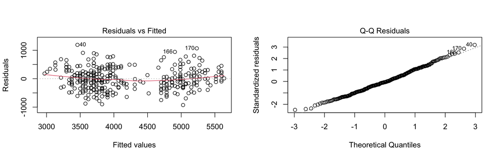

```r
par(mfrow = c(1, 2))
plot(fit_lm, which = 1:2)
```

**Left:** no curve or funnel shape → the relationship is straight and the spread is even. **Right:** points near the line → residuals are roughly normal.

## Report it

Give the estimate, its confidence interval, the test statistic and p-value, and the sample size.

> Body mass increased by 40.7 g per mm of flipper length (95% CI 34.7 to 46.7; t(338) = 13.3, p < 0.001), controlling for species (n = 342).

Every number in that sentence came from R, not typed by hand. Module 4 shows how to keep it that way.

## Exercise: statistics 5 min

Do male and female **Gentoo** penguins differ in **flipper length**?

1. Make a data frame of Gentoo penguins with a recorded sex.
2. Run a t-test.
3. Write one sentence reporting the result.

```r
gentoo <- penguins |>
  filter(species == "Gentoo", !is.na(sex))

t.test(flipper_length_mm ~ sex, data = gentoo)
```

Males’ flippers were longer by about **8.8 mm** (95% CI 7.1 to 10.6 mm; p < 0.001).

## Beyond today

| Your data | Model | Package |
| --- | --- | --- |
| Repeated measures, people within groups | Mixed model | lme4 |
| Yes/no outcomes, counts, proportions | Generalized linear model | base R: `glm()` |
| Curved trends | Generalized additive model | mgcv |
| Time until an event | Survival analysis | survival |

Same formula idea throughout: `outcome ~ predictors`.

# Module 4: Reproducible reports

15 minutes

## The copy-paste problem

- You run the analysis, then **type** the numbers into Word and paste in the figures.
- A reviewer asks you to drop three outliers.
- Now every number, table and figure has to be found and fixed by hand. Something gets missed.

**Quarto** puts the text, the code and its results in one file. Change the data, click **Render**, and everything updates.

## A Quarto document has three parts

**1. Header**: settings

```yaml
---
title: "Penguin report"
author: "Your Name"
format: html
---
```

**2. Text**: written normally

```markdown
## Results

Gentoo penguins were
the heaviest species.
```

**3. Code chunks**: run R

````markdown
```{r}
fit <- lm(body_mass_g ~
  species, data = penguins)
```
````

File → New File → **Quarto Document**. Click **Render** (Ctrl/Cmd+Shift+K) to produce HTML, Word or PDF.

## Inline code: numbers that write themselves

Put R code inside a sentence with a backtick and `r`:

```markdown
The study measured `r nrow(penguins)` penguins
of `r n_distinct(penguins$species)` species.
```

When you render, that becomes:

> The study measured 344 penguins of 3 species.

Change the data and re-render, and the sentence updates itself.

## Try it 5 min

1. File → New File → Quarto Document. Give it a title, untick “Use visual markdown editor”, click Create.
2. Delete the example text. Add a chunk (**Ctrl+Alt+I** / **Cmd+Option+I**) with `library(tidyverse)`, `library(palmerpenguins)` and one plot from today.
3. Write one sentence with an inline number, such as the number of penguins: `` `r nrow(penguins)` ``.
4. Save it in your project and click **Render**.

## Make it last

| Tool | What it does | Command |
| --- | --- | --- |
| **Quarto** | Report regenerates from code | Render |
| **renv** | Records the exact package versions you used | `renv::init()`, then `renv::snapshot()` |
| `sessionInfo()` | Prints R and package versions; put it at the end of reports | `sessionInfo()` |
| **Git + GitHub** | A history of every change, and a backup | RStudio’s Git pane |

**The test:** restart R, render the report. If it works, your analysis is reproducible.

# Wrap-up

## Take-home project

In your RStudio Project, write one Quarto report that:

1. Reads `data/raw/penguins_raw.csv` and cleans the column names
2. Makes one summary table with `group_by()` and `summarise()`
3. Makes one figure and saves it with `ggsave()`
4. Runs one statistical test and reports it with inline numbers
5. Ends with `sessionInfo()`

Restart R and render. If it renders, you’re done.

## Where to go next

- [R for Data Science (2e)](https://r4ds.hadley.nz/): free; covers everything today in more depth, plus joining tables
- [Posit cheat sheets](https://posit.co/resources/cheatsheets/): one-page references for dplyr, ggplot2 and Quarto
- [The Carpentries R lessons](https://datacarpentry.org/lessons/): workshop material by field
- [Quarto guide](https://quarto.org/docs/guide/): documents, slides, websites
- [Happy Git and GitHub for the useR](https://happygitwithr.com/): setting up version control

Cite R and its packages in your methods: `citation()` and `citation("emmeans")` print the reference.